# Pricing a Used Toyota Corolla

Shan Wang

27 February, 2020

# 1 Loading and Preprocessing the Data Set

Load required packages.

```r
library(mxnet)
library(caret)
library(forecast)
```

Let us read the data set:

```r
toyota.df <- read.csv("ToyotaCorolla.csv")
str(toyota.df)
```

```
## 'data.frame':    1436 obs. of  39 variables:
##  $ Id               : int  1 2 3 4 5 6 7 8 9 10 ...
##  $ Model            : Factor w/ 372 levels " TOYOTA Corolla 1.3 16V HATCHB G6 2/3-Doors",..: 332 332 67 332 331 331 64 326 62 59 ...
##  $ Price            : int  13500 13750 13950 14950 13750 12950 16900 18600 21500 12950 ...
##  $ Age_08_04        : int  23 23 24 26 30 32 27 30 27 23 ...
##  $ Mfg_Month        : int  10 10 9 7 3 1 6 3 6 10 ...
##  $ Mfg_Year         : int  2002 2002 2002 2002 2002 2002 2002 2002 2002 2002 ...
##  $ KM               : int  46986 72937 41711 48000 38500 61000 94612 75889 19700 71138 ...
##  $ Fuel_Type        : Factor w/ 3 levels "CNG","Diesel",..: 2 2 2 2 2 2 2 2 3 2 ...
##  $ HP               : int  90 90 90 90 90 90 90 90 192 69 ...
##  $ Met_Color        : int  1 1 1 0 0 0 1 1 0 0 ...
##  $ Color            : Factor w/ 10 levels "Beige","Black",..: 3 7 3 2 2 9 5 5 6 3 ...
##  $ Automatic        : int  0 0 0 0 0 0 0 0 0 0 ...
##  $ CC               : int  2000 2000 2000 2000 2000 2000 2000 2000 1800 1900 ...
##  $ Doors            : int  3 3 3 3 3 3 3 3 3 3 ...
```

[output cut: 25 more lines]

We will use predictors *Age_08_04*, *KM*, *Fuel_Type*, *HP*, *Automatic*, *Doors*, *Quarterly_Tax*, *Mfr_Guarantee*, *Guarantee_Period*, *Airco*, *Automatic_airco*, *CD_Player*, *Powered_Windows*, *Sport_Model* and *Tow_Bar* to predict *Price*.

So delete irrelavant variables.

```r
toyota=toyota.df[,-c(1,2,5,6,10,11,13,15,16,18,20,22,23,24,27,29,31,32,33,35,36,37,38)]
str(toyota)
```

```
## 'data.frame':    1436 obs. of  16 variables:
##  $ Price           : int  13500 13750 13950 14950 13750 12950 16900 18600 21500 12950 ...
##  $ Age_08_04       : int  23 23 24 26 30 32 27 30 27 23 ...
##  $ KM              : int  46986 72937 41711 48000 38500 61000 94612 75889 19700 71138 ...
##  $ Fuel_Type       : Factor w/ 3 levels "CNG","Diesel",..: 2 2 2 2 2 2 2 2 3 2 ...
##  $ HP              : int  90 90 90 90 90 90 90 90 192 69 ...
##  $ Automatic       : int  0 0 0 0 0 0 0 0 0 0 ...
##  $ Doors           : int  3 3 3 3 3 3 3 3 3 3 ...
##  $ Quarterly_Tax   : int  210 210 210 210 210 210 210 210 100 185 ...
##  $ Mfr_Guarantee   : int  0 0 1 1 1 0 0 1 0 0 ...
##  $ Guarantee_Period: int  3 3 3 3 3 3 3 3 3 3 ...
##  $ Airco           : int  0 1 0 0 1 1 1 1 1 1 ...
##  $ Automatic_airco : int  0 0 0 0 0 0 0 0 0 0 ...
##  $ CD_Player       : int  0 1 0 0 0 0 0 1 0 0 ...
##  $ Powered_Windows : int  1 0 0 0 1 1 1 1 1 0 ...
##  $ Sport_Model     : int  0 0 0 0 0 0 1 0 0 0 ...
##  $ Tow_Bar         : int  0 0 0 0 0 0 0 0 0 0 ...
```

Great dummies for *Fuel_Type*. If *toyota$Fuel_Type == "CNG"* then we set *toyota$Fuel_Type_CNG <- 1*; If *toyota$Fuel_Type == "Diesel"* then we set *toyota$Fuel_Type_Diesel <- 1*. And delete variable *Fuel_Type*.

```r
toyota$Fuel_Type_CNG <- 1* (toyota$Fuel_Type == "CNG")
toyota$Fuel_Type_Diesel <- 1* (toyota$Fuel_Type == "Diesel")
toyota=toyota[,-4]
str(toyota)
```

```
## 'data.frame':    1436 obs. of  17 variables:
##  $ Price           : int  13500 13750 13950 14950 13750 12950 16900 18600 21500 12950 ...
##  $ Age_08_04       : int  23 23 24 26 30 32 27 30 27 23 ...
##  $ KM              : int  46986 72937 41711 48000 38500 61000 94612 75889 19700 71138 ...
##  $ HP              : int  90 90 90 90 90 90 90 90 192 69 ...
##  $ Automatic       : int  0 0 0 0 0 0 0 0 0 0 ...
##  $ Doors           : int  3 3 3 3 3 3 3 3 3 3 ...
##  $ Quarterly_Tax   : int  210 210 210 210 210 210 210 210 100 185 ...
##  $ Mfr_Guarantee   : int  0 0 1 1 1 0 0 1 0 0 ...
##  $ Guarantee_Period: int  3 3 3 3 3 3 3 3 3 3 ...
##  $ Airco           : int  0 1 0 0 1 1 1 1 1 1 ...
##  $ Automatic_airco : int  0 0 0 0 0 0 0 0 0 0 ...
##  $ CD_Player       : int  0 1 0 0 0 0 0 1 0 0 ...
##  $ Powered_Windows : int  1 0 0 0 1 1 1 1 1 0 ...
##  $ Sport_Model     : int  0 0 0 0 0 0 1 0 0 0 ...
##  $ Tow_Bar         : int  0 0 0 0 0 0 0 0 0 0 ...
##  $ Fuel_Type_CNG   : num  0 0 0 0 0 0 0 0 0 0 ...
##  $ Fuel_Type_Diesel: num  1 1 1 1 1 1 1 1 0 1 ...
```

For the label *price*, we usally take log.

```r
toyota$Price=log(toyota$Price)
```

Split the data set to training and validation set. We use another function *sample()* here.

```r
set.seed(1)
train.index <- sample(row.names(toyota), 0.6*dim(toyota)[1])
valid.index <- setdiff(row.names(toyota), train.index)
train <- toyota[train.index, ]
valid <- toyota[valid.index, ]
```

We firsty use function *preProcess* in package *caret* to scale the numeric variables to 0-1, and save the transformation to *preProcValues*. Then use *predict()* to apply the transformation on the data.

```r
preProcValues=preProcess(train,method = "range",rangeBounds = c(0,1))
trainTransformed <- predict(preProcValues, train)
validTransformed <- predict(preProcValues, valid)
str(validTransformed)
```

```
## 'data.frame':    575 obs. of  17 variables:
##  $ Price           : num  0.563 0.572 0.614 0.795 0.542 ...
##  $ Age_08_04       : num  0.278 0.278 0.316 0.329 0.278 ...
##  $ KM              : num  0.2154 0.3344 0.2201 0.0903 0.3261 ...
##  $ HP              : num  0.171 0.171 0.171 1 0 ...
##  $ Automatic       : num  0 0 0 0 0 0 0 0 0 0 ...
##  $ Doors           : num  0.333 0.333 0.333 0.333 0.333 ...
##  $ Quarterly_Tax   : num  0.723 0.723 0.723 0.307 0.629 ...
##  $ Mfr_Guarantee   : num  0 0 1 0 0 1 1 0 0 0 ...
##  $ Guarantee_Period: num  0 0 0 0 0 ...
##  $ Airco           : num  0 1 0 1 1 1 1 1 1 1 ...
##  $ Automatic_airco : num  0 0 0 0 0 1 1 1 0 1 ...
##  $ CD_Player       : num  0 1 0 0 0 0 1 0 0 1 ...
##  $ Powered_Windows : num  1 0 0 1 0 1 1 1 1 1 ...
##  $ Sport_Model     : num  0 0 0 0 0 1 1 1 0 1 ...
##  $ Tow_Bar         : num  0 0 0 0 0 0 0 0 1 1 ...
##  $ Fuel_Type_CNG   : num  0 0 0 0 0 0 0 0 0 0 ...
##  $ Fuel_Type_Diesel: num  1 1 1 0 1 0 0 0 0 0 ...
```

Now we finish the preprocessing.

# 2 Training the Neural Network

We will use *mx.mlp()* function in package *mxnet*. *data* and *label* indicate the x and y. let us creat them firstly.

```r
train.x=data.matrix(trainTransformed[,2:17])
train.y=trainTransformed[,1]
```

*hidden_node*: number of nodes in hidden layers. *c(2,3)* indicating there are 2 hidden layers, the first hidden layer has 2 neurons and the second one has 3.

*out_node=1*: since we have regression problem, we have 1 node in output layer.

*out_activation=“rmse”*: activation function in output layer; default is softmax for classification problem.

*array.layout=“rowmajor”*: if row is an instance of data

*num.round*: number of iterations

*array.batch.size*: number of samples in each batch

*learning.rate*: the learning rate in gradient descent

*momentum*: Gradient Descent with Momentum considers the past gradients to smooth out the update. It computes an exponentially weighted average of your gradients, and then use that gradient to update your weights instead. It works faster than the standard gradient descent algorithm. It is a number between 0 to 1.

*eval_metric*: evaluate metric. Classification problem can use *mx.metric.accuracy*

```r
mx.set.seed(1)
model<-mx.mlp(train.x, train.y, hidden_node=c(4,4), activation = "tanh",out_node=1,out_activation="rmse",array.layout="rowmajor", num.round=50, array.batch.size=15, learning.rate=0.1, momentum=0.9, eval.metric=mx.metric.rmse)
```

The weights and bias in the generated neural network can be found by *model$arg.params*.

```r
model$arg.params
```

```
## $fullyconnected0_weight
##           [,1]    [,2]     [,3]    [,4]
##  [1,]  0.00025  0.0027  0.02277  0.0151
##  [2,]  0.00766  0.0075  0.01551  0.0132
##  [3,] -0.00183 -0.0020  0.00661 -0.0018
##  [4,] -0.00529  0.0043  0.00104 -0.0078
##  [5,]  0.00326 -0.0119 -0.01262  0.0011
##  [6,] -0.00109 -0.0043  0.00303 -0.0022
##  [7,]  0.00868 -0.0075 -0.01746 -0.0109
##  [8,] -0.00517  0.0077 -0.00215  0.0016
##  [9,] -0.00410 -0.0028 -0.01465 -0.0148
## [10,]  0.00434 -0.0148 -0.01782 -0.0144
## [11,]  0.00371 -0.0116 -0.01721 -0.0150
## [12,]  0.00649 -0.0046 -0.01565 -0.0021
## [13,] -0.00099 -0.0080 -0.01173  0.0012
## [14,] -0.00584  0.0045  0.00917  0.0029
## [15,] -0.00601  0.0089 -0.00094 -0.0065
## [16,]  0.00630  0.0079 -0.00445 -0.0066
##
## $fullyconnected0_bias
## [1] -7.0e-06  1.8e-05  4.9e-05  4.4e-06
##
## $fullyconnected1_weight
##         [,1]    [,2]   [,3]    [,4]
## [1,] -0.0049 -0.0079 -0.002 -0.0054
## [2,] -0.0039  0.0121 -0.011  0.0146
## [3,] -0.0119  0.0170 -0.030  0.0316
## [4,]  0.0043  0.0171 -0.024  0.0128
##
## $fullyconnected1_bias
## [1] -3.5e-05  6.2e-05  4.0e-05  1.2e-04
##
## $fullyconnected2_weight
##         [,1]
## [1,]  0.0059
## [2,] -0.0199
## [3,]  0.0294
## [4,] -0.0271
##
## $fullyconnected2_bias
## [1] 0.43
```

# 3 Predict the validation set

Use trained model to predict test set. *predit()* here will use *model* to predict *valid.x*.

```r
valid.x=data.matrix(validTransformed[,2:17])
valid.y=validTransformed[,1]
preds = predict(model, valid.x, array.layout="rowmajor")
preds=as.vector(preds)
```

The prediction accuracy can be calculated by function *accuracy()* in package *forecast*.

```r
accu=accuracy(preds, valid.y)
accu
```

```
##               ME RMSE  MAE MPE MAPE
## Test set -0.0065 0.14 0.11 -14   30
```

The valid-rmse is 0.14.

ME: Mean Error

RMSE: Root Mean Squared Error

MAE: Mean Absolute Error

MPE: Mean Percentage Error

MAPE: Mean Absolute Percentage Error

# 4 Tune the Model

Let us decrease the learning rate and increase the number of ierations. And simplfy the model by *dropout*.

*dropout* here is a number in [0,1) containing the dropout ratio from the last hidden layer to the output layer.

```r
mx.set.seed(1)
model2<-mx.mlp(train.x, train.y, hidden_node=c(4,5), activation = "tanh",out_node=1, dropout=0.2, out_activation="rmse",array.layout="rowmajor", num.round=100, array.batch.size=15, learning.rate=0.05, momentum=0.9, eval.metric=mx.metric.rmse)
```

Let us check the accuracy.

```r
preds2 = as.vector(predict(model2, valid.x, array.layout="rowmajor"))
accu2=accuracy(preds2, valid.y)
accu2
```

```
##               ME  RMSE  MAE  MPE MAPE
## Test set -0.0045 0.051 0.04 -3.6   11
```

The valid-rmse is 0.05, which is better than the previous model.

## 4.1 Plot the Predicted Price and True Price

The current preds2 are the labels normalized. Let us reset them.

```r
real.preds2=exp(preds2*(max(train[,1])-min(train[,1]))+min(train[,1]))
real.valid.y=exp(valid[,1])
```

Let us use *ggplot()*, let us firstly combine the Predicted Price and True Price into one column. Use “Predict” or “True” to label them.

```r
result_compare2=rbind(cbind(seq(1:575),real.valid.y,rep("True",575)),cbind(seq(1:575),real.preds2,rep("Predict",575)))
```

Transform the matrix to data.frame.

```r
result_compare2=as.data.frame(result_compare2)
colnames(result_compare2)=c("Index","Price","Value")
```

We need to convert the index and price to numeric variables.

```r
result_compare2$Index=as.numeric(levels(result_compare2$Index))[result_compare2$Index]
result_compare2$Price=as.numeric(levels(result_compare2$Price))[result_compare2$Price]
```

Use *ggplot()* to plot them.

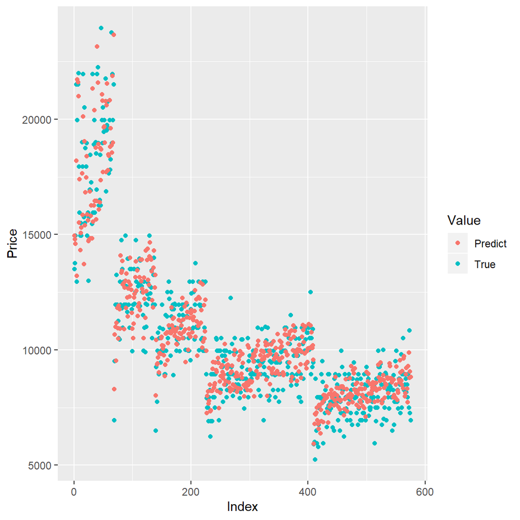

```r
ggplot(result_compare2, aes(x=Index, y=Price, colour=Value)) + geom_point()
```

Let us see the accuracy.

```r
accu3=accuracy(real.preds2, real.valid.y)
accu3
```

```
##           ME RMSE MAE  MPE MAPE
## Test set -25 1067 821 -1.4  8.1
```

The mean absolute deviation is $821.

# 5 Trouble Shooting

Package installation failure. Please try the following codes.

```r
cran <- getOption("repos")
cran["dmlc"] <- "https://s3-us-west-2.amazonaws.com/apache-mxnet/R/CRAN/"
options(repos = cran)
install.packages("mxnet",dependencies = T)
```

or

```r
install.packages("https://github.com/jeremiedb/mxnet_winbin/raw/master/mxnet.zip", repos = NULL)
```